# Titanic Competition

Trevor Aeschliman

July 10, 2017

## Getting the Data

```
##   PassengerId Survived Pclass
## 1           1        0      3
## 2           2        1      1
## 4           4        1      1
## 5           5        0      3
## 7           7        0      1
## 8           8        0      3
##                                                  Name    Sex Age SibSp
## 1                             Braund, Mr. Owen Harris   male  22     1
## 2 Cumings, Mrs. John Bradley (Florence Briggs Thayer) female  38     1
## 4        Futrelle, Mrs. Jacques Heath (Lily May Peel) female  35     1
## 5                            Allen, Mr. William Henry   male  35     0
## 7                             McCarthy, Mr. Timothy J   male  54     0
## 8                      Palsson, Master. Gosta Leonard   male   2     3
##   Parch    Ticket    Fare Cabin Embarked
## 1     0 A/5 21171  7.2500  <NA>        S
## 2     0  PC 17599 71.2833   C85        C
## 4     0    113803 53.1000  C123        S
## 5     0    373450  8.0500  <NA>        S
## 7     0     17463 51.8625   E46        S
## 8     1    349909 21.0750  <NA>        S
```

## Exporatory Analysis

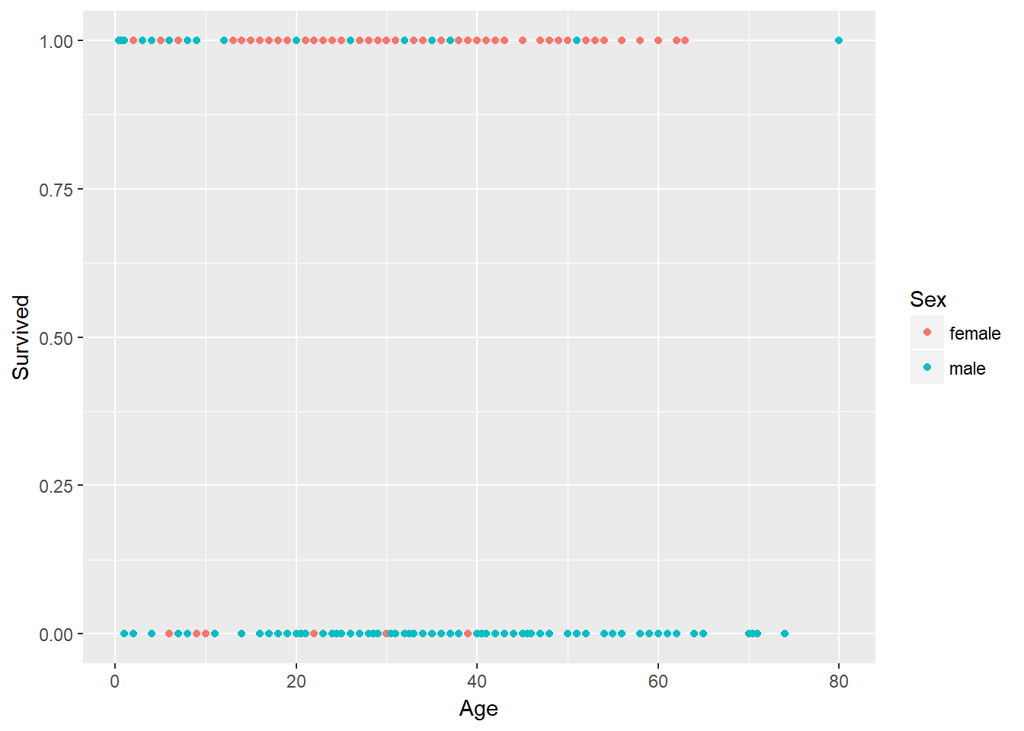

You can see that most of the females in the training set survived, and that age was spread pretty evenly for survivors between age 0 and age 55

## Model Fitting with Logistic Regression

We first try a boosted logistic regression using sex, age, siblings, parents, and class as predictors.

```r
#Fit model BOOSTED LOGISTIC REGRESSION
set.seed(100)


modelFit<- train(factor(Survived)~Sex+Age+SibSp+Parch+Pclass,data=training,method="LogitBoost")
#Make predictions on test set
predictions<-predict(modelFit,newdata=testing,type="raw")

#Confusion Matrix
confusionMatrix(predictions,testing$Survived)
```

```
## Confusion Matrix and Statistics
##
##           Reference
## Prediction   0   1
##          0 105  25
##          1  19  68
##
##                Accuracy : 0.7972
##                  95% CI : (0.7375, 0.8486)
##     No Information Rate : 0.5714
##     P-Value [Acc > NIR] : 1.925e-12
##
##                   Kappa : 0.5827
##  Mcnemar's Test P-Value : 0.451
##
##             Sensitivity : 0.8468
##             Specificity : 0.7312
##          Pos Pred Value : 0.8077
##          Neg Pred Value : 0.7816
##              Prevalence : 0.5714
##          Detection Rate : 0.4839
##    Detection Prevalence : 0.5991
##       Balanced Accuracy : 0.7890
##
##        'Positive' Class : 0
##
```

Because we saw that the majority of survivors were female, we will try boosted logistic regression with only sex as a predictor.

```r
#Fit model BOOSTED LOGISTIC REGRESSION
set.seed(100)
#training$Survived<-as.factor(training$Survived)
modelFit<- train(factor(Survived)~Sex,method="LogitBoost",data=training)

#Make predictions on test set
predictions<-predict(modelFit,newdata=testing,type="raw")

#Confusion Matrix
confusionMatrix(predictions,testing$Survived)
```

```
## Confusion Matrix and Statistics
##
##           Reference
## Prediction   0   1
##          0 106  28
##          1  18  65
##
##                Accuracy : 0.788
##                  95% CI : (0.7276, 0.8404)
##     No Information Rate : 0.5714
##     P-Value [Acc > NIR] : 1.602e-11
##
##                   Kappa : 0.5613
##  Mcnemar's Test P-Value : 0.1845
##
##             Sensitivity : 0.8548
##             Specificity : 0.6989
##          Pos Pred Value : 0.7910
##          Neg Pred Value : 0.7831
##              Prevalence : 0.5714
##          Detection Rate : 0.4885
##    Detection Prevalence : 0.6175
##       Balanced Accuracy : 0.7769
##
##        'Positive' Class : 0
##
```

Next, we try using cross-validation with our original set of features/predictors. This partitions the training set into 10 subsamples, and randomly chooses one of them as the test set and the other 9 as training sets, taking the average of the results of each of the 10 model runs.

```r
set.seed(100)
train$Age[is.na(train$Age)]<-mean(train$Age,na.rm=T)
control<- trainControl(method="cv", number=10, savePredictions = TRUE)


modelFit<- train(factor(Survived)~Sex+Age+SibSp+Parch+Pclass,data=train, trControl=control,method="LogitBoost")

#Make predictions on test set
predictions<-predict(modelFit,newdata=testing,type="raw")

#Confusion Matrix
confusionMatrix(predictions,testing$Survived)
```

```
## Confusion Matrix and Statistics
##
##           Reference
## Prediction   0   1
##          0 103  27
##          1  21  66
##
##                Accuracy : 0.7788
##                  95% CI : (0.7176, 0.8322)
##     No Information Rate : 0.5714
##     P-Value [Acc > NIR] : 1.197e-10
##
##                   Kappa : 0.5447
##  Mcnemar's Test P-Value : 0.4705
##
##             Sensitivity : 0.8306
##             Specificity : 0.7097
##          Pos Pred Value : 0.7923
##          Neg Pred Value : 0.7586
##              Prevalence : 0.5714
##          Detection Rate : 0.4747
##    Detection Prevalence : 0.5991
##       Balanced Accuracy : 0.7702
##
##        'Positive' Class : 0
##
```

## Model Fitting with Regularized Logistic Regression

Next, we try regularized logistic regression.

```r
##REGULARIZED LOGISTIC REGRESSION
set.seed(100)
training$Survived<-as.factor(training$Survived)
modelFit<- train(factor(Survived)~Sex+Age+SibSp+Parch+Pclass,method="glmnet",data=training)
#Make predictions on test set
predictions<-predict(modelFit,newdata=testing,type="raw")

#Confusion Matrix
confusionMatrix(predictions,testing$Survived)
```

```
## Confusion Matrix and Statistics
##
##           Reference
## Prediction   0   1
##          0 107  30
##          1  17  63
##
##                Accuracy : 0.7834
##                  95% CI : (0.7226, 0.8363)
##     No Information Rate : 0.5714
##     P-Value [Acc > NIR] : 4.437e-11
##
##                   Kappa : 0.5499
##  Mcnemar's Test P-Value : 0.08005
##
##             Sensitivity : 0.8629
##             Specificity : 0.6774
##          Pos Pred Value : 0.7810
##          Neg Pred Value : 0.7875
##              Prevalence : 0.5714
##          Detection Rate : 0.4931
##    Detection Prevalence : 0.6313
##       Balanced Accuracy : 0.7702
##
##        'Positive' Class : 0
##
```

## Model Fitting With a Tree Ensemble

Finally, we try XGBOOST, a tree ensemble.

```r
library(xgboost)
library(stringr)
library(caret)
library(car)

#remove columns with values of class "character", transform dataframe into matrix
trainingX<-trainingX[c(1:3,6:8,10)]
trainingX<-as.matrix(trainingX)
label<-trainingX[,2]
trainingX<-trainingX[,-2]

#Fit xgboost model to training set, using "Survived" variable as outcome
modelFit <- xgboost(data = trainingX, label=label, nrounds=4,objective = "binary:logistic")
#Remove "Survived" variable from testing set
testingX<-as.matrix(testing[c(1,3,6:8,10)])

predictions<-predict(modelFit,newdata=testingX)
prediction <- as.numeric(predictions > 0.5)

confusionMatrix(prediction,testing$Survived)
```

```
## Confusion Matrix and Statistics
##
##           Reference
## Prediction   0   1
##          0 100  47
##          1  24  46
##
##                Accuracy : 0.6728
##                  95% CI : (0.606, 0.7348)
##     No Information Rate : 0.5714
##     P-Value [Acc > NIR] : 0.00142
##
##                   Kappa : 0.3107
##  Mcnemar's Test P-Value : 0.00903
##
##             Sensitivity : 0.8065
##             Specificity : 0.4946
##          Pos Pred Value : 0.6803
##          Neg Pred Value : 0.6571
##              Prevalence : 0.5714
##          Detection Rate : 0.4608
##    Detection Prevalence : 0.6774
##       Balanced Accuracy : 0.6505
##
##        'Positive' Class : 0
##
```